# Reports

## Visual mode

Contrast with ‘source’ mode

## Code blocks or chunks

- names
- options: fig.cap=““, echo=FALSE, message=FALSE and many more
- [code chunk option tutorial](https://rmarkdown.rstudio.com/lesson-3.html) and [reference](https://bookdown.org/yihui/rmarkdown-cookbook/chunk-options.html)

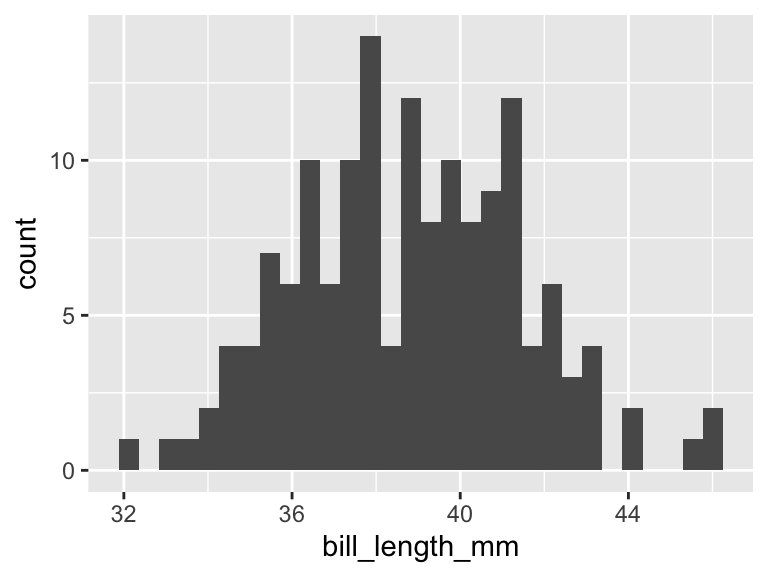

Figure 1. A histogram of penguin bill lengths (in mm).

## Computation model

- Work as you go and develop
  - Play button, command/control enter, typing in console
- Knitting to ensure everything “works”
- Output formats (HTML, MS Word, PDF, slides)

## Common mistakes

- forget a library function call (`library(tidyverse)`)
- read data from a path that exists only on your computer (projects and `here::here()` function)
- Computations out of sequence
- Leave R errors in your Rmd document

```r
read_csv("../tasks/test-data.csv")
```

```
## # A tibble: 3 × 5
##   Name        Birthdate  Mass_kg Species Friendly
##   <chr>       <date>       <dbl> <chr>   <lgl>
## 1 A nonymouse 2001-01-01    14.5 <NA>    FALSE
## 2 Frank       2008-09-01     4.1 Cat     TRUE
## 3 Boojum      1982-07-11     7.2 Dog     TRUE
```

```r
## read_csv("/Users/airwin/git-repos/Stat2430/data-viz-course/data-viz/tasks/test-data.csv")
read_csv(here::here("data-viz/tasks", "test-data.csv"))
```

```
## # A tibble: 3 × 5
##   Name        Birthdate  Mass_kg Species Friendly
##   <chr>       <date>       <dbl> <chr>   <lgl>
## 1 A nonymouse 2001-01-01    14.5 <NA>    FALSE
## 2 Frank       2008-09-01     4.1 Cat     TRUE
## 3 Boojum      1982-07-11     7.2 Dog     TRUE
```

## How Rstudio tries to help

- Red X sign
- underlines
- Environment viewer

```r
model1 <- lm(body_mass_g ~ species,
             data = penguins)  # delete bracket to see red X
summary(model1)
```

```
##
## Call:
## lm(formula = body_mass_g ~ species, data = penguins)
##
## Residuals:
##      Min       1Q   Median       3Q      Max
## -1126.02  -333.09   -33.09   316.91  1223.98
##
## Coefficients:
##                  Estimate Std. Error t value Pr(>|t|)
## (Intercept)       3700.66      37.62   98.37   <2e-16 ***
## speciesChinstrap    32.43      67.51    0.48    0.631
## speciesGentoo     1375.35      56.15   24.50   <2e-16 ***
## ---
## Signif. codes:  0 '***' 0.001 '**' 0.01 '*' 0.05 '.' 0.1 ' ' 1
##
## Residual standard error: 462.3 on 339 degrees of freedom
##   (2 observations deleted due to missingness)
## Multiple R-squared:  0.6697, Adjusted R-squared:  0.6677
## F-statistic: 343.6 on 2 and 339 DF,  p-value: < 2.2e-16
```

```r
p1 <- penguins |> ggplot(aes(body_mass_g)) + geom_histogram()
```

## Concepts to reinforce and reexplain

- Objects come in different types
  - numbers, text, dates
  - tables
  - plots
  - models (of various kinds)
  - many more
- How to learn about the object you’ve created
  - type name in console
  - look in environment tab
- Chain commands together with pipes (`|>` or `%>%`) vs. assigning objects to temporary names to break down computations into component parts

Do a calculation two ways: with just pipes, and then in a series of steps with named objects I’ll create.

```r
penguins |> na.omit() |>
  group_by(species) |>
  summarize(mean_body_mass = mean(body_mass_g))
```

```
## # A tibble: 3 × 2
##   species   mean_body_mass
##   <fct>              <dbl>
## 1 Adelie             3706.
## 2 Chinstrap          3733.
## 3 Gentoo             5092.
```

```r
penguins |> summarize(mean_flipper_lenght = mean(flipper_length_mm))
```

```
## # A tibble: 1 × 1
##   mean_flipper_lenght
##                 <dbl>
## 1                  NA
```

“step-by-step”

```r
penguins_no_na <- penguins |> na.omit()
penguins_group <- penguins_no_na |> group_by(species)
penguins_group |> summarize(mean_body_mass = mean(body_mass_g))
```

```
## # A tibble: 3 × 2
##   species   mean_body_mass
##   <fct>              <dbl>
## 1 Adelie             3706.
## 2 Chinstrap          3733.
## 3 Gentoo             5092.
```

```r
penguins_no_na |> summarize(mean_flipper_lenght = mean(flipper_length_mm))
```

```
## # A tibble: 1 × 1
##   mean_flipper_lenght
##                 <dbl>
## 1                201.
```